# Week4-Project_Final

Serge Toulzac

6 juin 2018

## Library loading

```r
library(caret)
library(rpart)
library(dplyr)
library (ggplot2)
library(ISLR)
library(snow)
library(parallel)
library(doParallel)
library(rpart.plot)
```

## Data loading

```r
trainURL <- "https://d396qusza40orc.cloudfront.net/predmachlearn/pml-training.csv"
testURL <- "https://d396qusza40orc.cloudfront.net/predmachlearn/pml-testing.csv"

rawData <- read.csv(url(trainURL), na.strings=c("NA","#DIV/0!", ""))
test <- read.csv(url(testURL))
```

## Seed

```r
set.seed(111)
```

## Explonatory Analysis

#### Removing columns that will not be used:

- X
- user_name
- raw_timestamp_part_1
- raw_timestamp_part_2
- cvtd_timestamp
- new_window

```r
rawData <- subset(rawData, select=-c(X,user_name,raw_timestamp_part_1,raw_timestamp_part_2,cvtd_timestamp,new_window))
```

#### Removing data with large number of NA values (keep columns who have more than 80% of real values)

```r
rawData <- rawData [, colSums(!is.na(rawData))>(nrow(rawData)* .8)]
```

#### remove highly corelated predictor (> 0.7)

```r
corMatrix <- cor(rawData[,-54])
highCor <- findCorrelation(corMatrix,cutoff = .7)
cleanData <- rawData[,-highCor]
rm(corMatrix)
rm(rawData)
```

#### Cross-validation

I will separate the training set in two data set (train (70%) and validation (30%)) I will then be able to have information on how does my models and have an accuracy not calculated on the training data set. Accuracy on validation set will be less than train set accuracy.

```r
partition <- createDataPartition(y=cleanData$classe, p=0.7, list=FALSE)
train <- cleanData[partition,]
validation <- cleanData[-partition,]
rm(partition)
```

## Pre-processing

#### Removing Data with Near Zero Variance

```r
nsv <- nearZeroVar(cleanData, saveMetrics = TRUE)
cleanData <- cleanData[, !nsv$nzv]
rm(nsv)
```

## Modeling

All modles will preProcess the data:

- Center
- scale
- BoxCox

#### Parameter tuning

```r
tr_cont2 <- trainControl(method = "cv",number = 5,  allowParallel = TRUE, classProbs = TRUE, summaryFunction=mnLogLoss)
```

LogLoss will be used for monitoring the performance of the training and select the “final” model of each models.

logLoss is best choice for “multiclass” classifcation probleme (while ROC is best for binary classification)

### Decision Tree

```r
control <- trainControl(method="repeatedcv", number=3, repeats = 5, classProbs=TRUE, summaryFunction=mnLogLoss)
model_dt <- train(classe ~ ., data = train, preProcess=c("center", "scale", "BoxCox"), trControl=tr_cont2, method="rpart", metric="logLoss")
model_dt
```

```
## CART
##
## 13737 samples
##    31 predictor
##     5 classes: 'A', 'B', 'C', 'D', 'E'
##
## Pre-processing: centered (31), scaled (31), Box-Cox transformation (3)
## Resampling: Cross-Validated (5 fold)
## Summary of sample sizes: 10989, 10988, 10989, 10991, 10991
## Resampling results across tuning parameters:
##
##   cp          logLoss
##   0.03987387  1.217188
##   0.04384091  1.262134
##   0.05767470  1.412472
##
## logLoss was used to select the optimal model using the smallest value.
## The final value used for the model was cp = 0.03987387.
```

```r
pred_dt <- predict(model_dt, newdata=validation)
confusionMatrix(pred_dt,validation$classe)
```

```
## Confusion Matrix and Statistics
##
##           Reference
## Prediction    A    B    C    D    E
##          A 1402  208  114  269  293
##          B   87  239   35   91    9
##          C  185  691  877  525  442
##          D    0    0    0    0    0
##          E    0    1    0   79  338
##
## Overall Statistics
##
##                Accuracy : 0.4853
##                  95% CI : (0.4725, 0.4982)
##     No Information Rate : 0.2845
##     P-Value [Acc > NIR] : < 2.2e-16
##
##                   Kappa : 0.3407
##  Mcnemar's Test P-Value : < 2.2e-16
##
## Statistics by Class:
##
##                      Class: A Class: B Class: C Class: D Class: E
## Sensitivity            0.8375  0.20983   0.8548   0.0000  0.31238
## Specificity            0.7901  0.95322   0.6207   1.0000  0.98334
## Pos Pred Value         0.6133  0.51844   0.3224      NaN  0.80861
## Neg Pred Value         0.9244  0.83407   0.9529   0.8362  0.86391
## Prevalence             0.2845  0.19354   0.1743   0.1638  0.18386
## Detection Rate         0.2382  0.04061   0.1490   0.0000  0.05743
## Detection Prevalence   0.3884  0.07833   0.4622   0.0000  0.07103
## Balanced Accuracy      0.8138  0.58153   0.7377   0.5000  0.64786
```

### Random Forest

```r
cluster <- makeCluster(detectCores() -1 )
registerDoParallel(cluster)

model_rf <- train(classe ~ ., data = train, preProcess=c("center", "scale","BoxCox"), method = "rf", metric="logLoss", trControl = tr_cont2, verbose = FALSE)

stopCluster(cluster)
registerDoSEQ()

model_rf
```

```
## Random Forest
##
## 13737 samples
##    31 predictor
##     5 classes: 'A', 'B', 'C', 'D', 'E'
##
## Pre-processing: centered (31), scaled (31), Box-Cox transformation (3)
## Resampling: Cross-Validated (5 fold)
## Summary of sample sizes: 10988, 10989, 10991, 10989, 10991
## Resampling results across tuning parameters:
##
##   mtry  logLoss
##    2    0.20010596
##   16    0.07637861
##   31    0.05136596
##
## logLoss was used to select the optimal model using the smallest value.
## The final value used for the model was mtry = 31.
```

```r
pred_rf <- predict(model_rf, newdata= validation)
confusionMatrix(pred_rf, validation$classe)
```

```
## Confusion Matrix and Statistics
##
##           Reference
## Prediction    A    B    C    D    E
##          A 1671   10    0    0    0
##          B    3 1127    6    0    3
##          C    0    2 1019    4    1
##          D    0    0    0  960    2
##          E    0    0    1    0 1076
##
## Overall Statistics
##
##                Accuracy : 0.9946
##                  95% CI : (0.9923, 0.9963)
##     No Information Rate : 0.2845
##     P-Value [Acc > NIR] : < 2.2e-16
##
##                   Kappa : 0.9931
##  Mcnemar's Test P-Value : NA
##
## Statistics by Class:
##
##                      Class: A Class: B Class: C Class: D Class: E
## Sensitivity            0.9982   0.9895   0.9932   0.9959   0.9945
## Specificity            0.9976   0.9975   0.9986   0.9996   0.9998
## Pos Pred Value         0.9941   0.9895   0.9932   0.9979   0.9991
## Neg Pred Value         0.9993   0.9975   0.9986   0.9992   0.9988
## Prevalence             0.2845   0.1935   0.1743   0.1638   0.1839
## Detection Rate         0.2839   0.1915   0.1732   0.1631   0.1828
## Detection Prevalence   0.2856   0.1935   0.1743   0.1635   0.1830
## Balanced Accuracy      0.9979   0.9935   0.9959   0.9977   0.9971
```

### Gradient Boosting Machine

```r
cluster <- makeCluster(detectCores()-1)
registerDoParallel(cluster)

model_gbm <- trainControl(method="cv",number=5, allowParallel=TRUE)
timer_start <- Sys.time()
model_gbm <- train(classe ~ ., data = train, preProcess=c("center", "scale","BoxCox"), method = "gbm", metric="logLoss",  trControl = tr_cont2, verbose =FALSE)

stopCluster(cluster)
registerDoSEQ()

model_gbm
```

```
## Stochastic Gradient Boosting
##
## 13737 samples
##    31 predictor
##     5 classes: 'A', 'B', 'C', 'D', 'E'
##
## Pre-processing: centered (31), scaled (31), Box-Cox transformation (3)
## Resampling: Cross-Validated (5 fold)
## Summary of sample sizes: 10989, 10990, 10990, 10989, 10990
## Resampling results across tuning parameters:
##
##   interaction.depth  n.trees  logLoss
##   1                   50      0.9675949
##   1                  100      0.7900769
##   1                  150      0.6713363
##   2                   50      0.6636769
##   2                  100      0.4128987
##   2                  150      0.2809290
##   3                   50      0.4708734
##   3                  100      0.2453630
##   3                  150      0.1448010
##
## Tuning parameter 'shrinkage' was held constant at a value of 0.1
##
## Tuning parameter 'n.minobsinnode' was held constant at a value of 10
## logLoss was used to select the optimal model using the smallest value.
## The final values used for the model were n.trees = 150,
##  interaction.depth = 3, shrinkage = 0.1 and n.minobsinnode = 10.
```

```r
pred_gbm <- predict(model_gbm, newdata = validation)
confusionMatrix(pred_gbm,validation$classe)
```

```
## Confusion Matrix and Statistics
##
##           Reference
## Prediction    A    B    C    D    E
##          A 1672    6    0    1    0
##          B    2 1124   11    2    1
##          C    0    4 1013   13    4
##          D    0    3    2  943   11
##          E    0    2    0    5 1066
##
## Overall Statistics
##
##                Accuracy : 0.9886
##                  95% CI : (0.9856, 0.9912)
##     No Information Rate : 0.2845
##     P-Value [Acc > NIR] : < 2.2e-16
##
##                   Kappa : 0.9856
##  Mcnemar's Test P-Value : NA
##
## Statistics by Class:
##
##                      Class: A Class: B Class: C Class: D Class: E
## Sensitivity            0.9988   0.9868   0.9873   0.9782   0.9852
## Specificity            0.9983   0.9966   0.9957   0.9967   0.9985
## Pos Pred Value         0.9958   0.9860   0.9797   0.9833   0.9935
## Neg Pred Value         0.9995   0.9968   0.9973   0.9957   0.9967
## Prevalence             0.2845   0.1935   0.1743   0.1638   0.1839
## Detection Rate         0.2841   0.1910   0.1721   0.1602   0.1811
## Detection Prevalence   0.2853   0.1937   0.1757   0.1630   0.1823
## Balanced Accuracy      0.9986   0.9917   0.9915   0.9875   0.9919
```

### SVM Radial

```r
cluster <- makeCluster(detectCores()-1)
registerDoParallel(cluster)

model_svm <- trainControl(method="cv",number=5, allowParallel=TRUE)

model_svm <- train(classe ~ ., data = train, preProcess=c("center", "scale","BoxCox"), method = "svmRadial",  tuneLength=5, metric="logLoss",  trControl = tr_cont2, verbose =FALSE)

stopCluster(cluster)
registerDoSEQ()

model_svm
```

```
## Support Vector Machines with Radial Basis Function Kernel
##
## 13737 samples
##    31 predictor
##     5 classes: 'A', 'B', 'C', 'D', 'E'
##
## Pre-processing: centered (31), scaled (31), Box-Cox transformation (3)
## Resampling: Cross-Validated (5 fold)
## Summary of sample sizes: 10990, 10989, 10990, 10989, 10990
## Resampling results across tuning parameters:
##
##   C     logLoss
##   0.25  0.6527774
##   0.50  0.5945463
##   1.00  0.5530126
##   2.00  0.5138057
##   4.00  0.4806132
##
## Tuning parameter 'sigma' was held constant at a value of 0.02036514
## logLoss was used to select the optimal model using the smallest value.
## The final values used for the model were sigma = 0.02036514 and C = 4.
```

```r
pred_svm <- predict(model_svm, newdata = validation)
confusionMatrix(pred_svm,validation$classe)
```

```
## Confusion Matrix and Statistics
##
##           Reference
## Prediction    A    B    C    D    E
##          A 1667   35   19  100   11
##          B    5 1038   57  141   81
##          C    0   66  816   91  119
##          D    0    0  133  393   56
##          E    2    0    1  239  815
##
## Overall Statistics
##
##                Accuracy : 0.8036
##                  95% CI : (0.7932, 0.8137)
##     No Information Rate : 0.2845
##     P-Value [Acc > NIR] : < 2.2e-16
##
##                   Kappa : 0.7502
##  Mcnemar's Test P-Value : < 2.2e-16
##
## Statistics by Class:
##
##                      Class: A Class: B Class: C Class: D Class: E
## Sensitivity            0.9958   0.9113   0.7953  0.40768   0.7532
## Specificity            0.9608   0.9402   0.9432  0.96159   0.9496
## Pos Pred Value         0.9099   0.7852   0.7473  0.67526   0.7711
## Neg Pred Value         0.9983   0.9779   0.9562  0.89233   0.9447
## Prevalence             0.2845   0.1935   0.1743  0.16381   0.1839
## Detection Rate         0.2833   0.1764   0.1387  0.06678   0.1385
## Detection Prevalence   0.3113   0.2246   0.1856  0.09890   0.1796
## Balanced Accuracy      0.9783   0.9257   0.8693  0.68463   0.8514
```

#### out-of-sample error

The accuracies calculated on test data are lower than accuracy the one caculated on the train data set, so no over fiting

## Models Comparision

```r
# Compare model performances using resample()
models_compare <- resamples(list(DT=model_dt, RF=model_rf,GBM=model_gbm,SVM=model_svm))

# Summary of the models performances
summary(models_compare)
```

```
##
## Call:
## summary.resamples(object = models_compare)
##
## Models: DT, RF, GBM, SVM
## Number of resamples: 5
##
## logLoss
##           Min.    1st Qu.     Median       Mean    3rd Qu.       Max. NA's
## DT  1.14359555 1.14538790 1.21532859 1.21718784 1.22977126 1.35185591    0
## RF  0.04684259 0.05086331 0.05131858 0.05136596 0.05333289 0.05447245    0
## GBM 0.13906787 0.14259288 0.14609748 0.14480105 0.14618784 0.15005918    0
## SVM 0.44788068 0.47640267 0.48467207 0.48061320 0.48903569 0.50507489    0
```

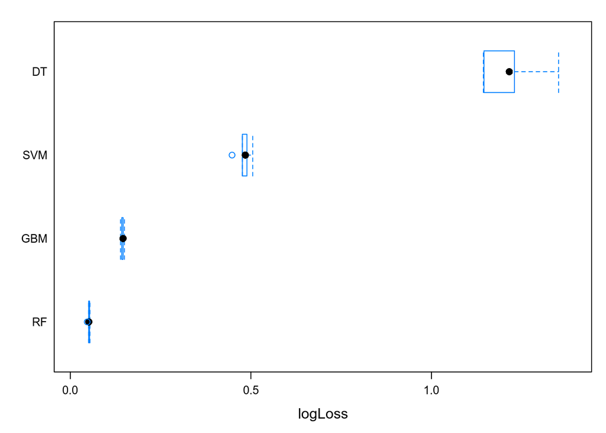

```r
scales <- list(x=list(relation="free"), y=list(relation="free"))
bwplot(models_compare, scales=scales)
```

Random Forest have the lowest logLoss value and therfore is better that Decision tree, Support Vector Machine and Gradient Boosting Machine

Random Forest have the best Accuracy on the validation data set: 99,46% with 99,23% < 95% CI < 99,63%

## s Prediction on Test data with Random Forest

```r
predicted <- predict(model_rf, test)
predicted
```

```
##  [1] B A B A A E D B A A B C B A E E A B B B
## Levels: A B C D E
```